[< back](https://www.jakobsalomonsson.com/)

# Tyre Maintenence

Maintaining proper wheel quality is incredibly important for good road safety. For organisations owning larger fleets of vehicles, taking them off the road for maintenance can be costly. Being able to better plan when maintenance is needed, and on what parts of the vehicle through smarter predictions can significantly reduce expenses.

In this project we collected images of tyres (~300 in total) to test the hypothesis on whether it's possible to predict the tyre tread depth on single camera input images using deep learning techniques. Despite the small dataset, we chose a design that can easily be scaled up to millions of samples with virtually no changes to the code.

Although the dataset is very small, this early-stage experiment seems to indicate that it *is* possible to predict the tread depth of tyres using deep learning techniques. More data should however be collected to verify the results with greater confidence. Another, plausible more important aspect, is whether it's easier to take a photo of sufficient quality of a tyre rather than just using current methods available on the market.

- Create Image Data Generators with Augmentation
- Train a simple model from scratch without Dropout
- Training a larger model from scratch
- Even larger model from scratch
- Using pre-trained models (Transfer Learning)
- Fine-tune the pre-trained model
- Summary

```python
import os
import re
import numpy as np
import pandas as pd
import tensorflow as tf
from tensorflow import keras
from tensorflow.keras.layers import Dropout, Dense, MaxPooling2D, Conv2D, SeparableConv2D
from tensorflow.keras import layers

import matplotlib.pyplot as plt
import seaborn as sns
sns.set()
```

```python
# Mount Google Drive to access the files stored there
from google.colab import drive
drive.mount('/content/drive')
```

Start by loading a batch of images and visualise them so we get a feeling for what we are working with.

```python
# Specify image size, batch size and data folder
image_size = (800, 380)
batch_size = 16
data_dir = '/content/drive/MyDrive/Tyres/Data_for_model/'
```

```python
# Data generator without augmentation
data_gen_wo_aug = tf.keras.preprocessing.image_dataset_from_directory(
    data_dir,
    batch_size=batch_size,
    image_size=image_size,
    seed=9119,
)
```

```
Found 315 files belonging to 4 classes.
```

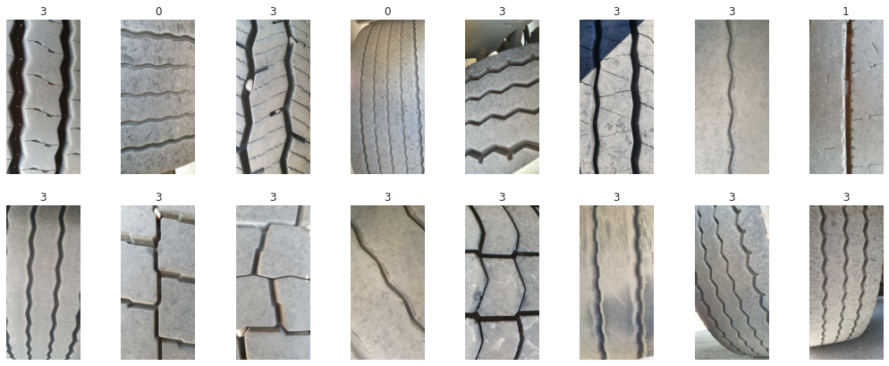

```python
plt.figure(figsize=(18, 7))
for images, labels in data_gen_wo_aug.take(1):
    for i in range(16):
        plt.subplot(2, 8, i+1)
        plt.imshow(images[i].numpy().astype('uint32'))
        plt.title(int(labels[i]))
        plt.axis('off')
```

The images look good. Since we have so little data I will do data augmentation directly, even though it introduces complexity at an early stage.

## Create Image Data Generators **with** Augmentation

```python
# Create folders for inspecting the augmented images
augmented_dir = '/content/drive/MyDrive/Tyres/Augmented_example_images/'
train_inspection_dir = augmented_dir + 'train_inspection'
validation_inspection_dir = augmented_dir + 'validation_inspection'

try:
    os.makedirs(train_inspection_dir)
    os.makedirs(validation_inspection_dir)
except FileExistsError:
    pass
```

```python
# Create an image data generator with augmentation on the train set
train_gen = tf.keras.preprocessing.image.ImageDataGenerator(
    rotation_range=45,
    brightness_range=[0.8, 1.2],
    zoom_range=0.1,
    shear_range=0.1,
    fill_mode='constant',
    horizontal_flip=True,
    vertical_flip=True,
    rescale=1./255,
    validation_split=0.2, # Use the last 20% of images as validation set.
)

# No augmentation on the validation set
validation_gen = tf.keras.preprocessing.image.ImageDataGenerator(
    rescale=1./255,
    validation_split=0.2, # Use the last 20% of images as validation set.
)

# Use the generator with augmentation on the train set
train_generator = train_gen.flow_from_directory(
    data_dir,
    target_size=image_size,
    batch_size=batch_size,
    class_mode='categorical', # with categorical labels we later have to use categorical_crossentropy loss
    seed=124,
    #save_to_dir=train_inspection_dir,  # Save images for inspection (these should be augmented)
    subset='training',                  # This is the training set
)

# No augmentation on the validation set
validation_generator = validation_gen.flow_from_directory(
    data_dir,
    target_size=image_size,
    batch_size=batch_size,
    class_mode='categorical',
    seed=124,
    #save_to_dir=validation_inspection_dir,  # Save images for inspection (these should NOT be augmented)
    subset='validation'                      # validation set
)
```

```
Found 252 images belonging to 4 classes.
Found 63 images belonging to 4 classes.
```

```python
# Take a quick look at what the train_generator outputs
for train_data_batch, train_label_batch in train_generator:
    print("Train data batch size:", train_data_batch.shape)
    print("Train label batch size:", train_label_batch.shape)
    break

# And the validation_generator
for val_data_batch, val_label_batch in validation_generator:
    print("Validation data batch size:", val_data_batch.shape)
    print("Validation label batch size:", val_label_batch.shape)
    break
```

```
Train data batch size: (16, 800, 380, 3)
Train label batch size: (16, 4)
Validation data batch size: (16, 800, 380, 3)
Validation label batch size: (16, 4)
```

They should be equal in terms of shape - and they are.

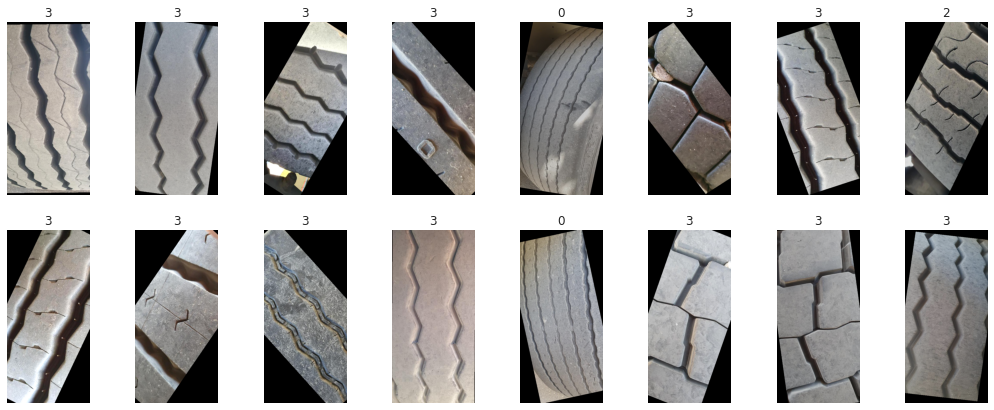

```python
# Sanity check with augmented images
plt.figure(figsize=(18, 7))
for images, labels in train_generator:
    for i in range(16):
        plt.subplot(2, 8, i+1)
        plt.imshow(images[i])
        plt.title(int(np.argmax(labels[i])))
        plt.axis('off')
    break
```

Conversely, there should be NO augmentation on the validation set.

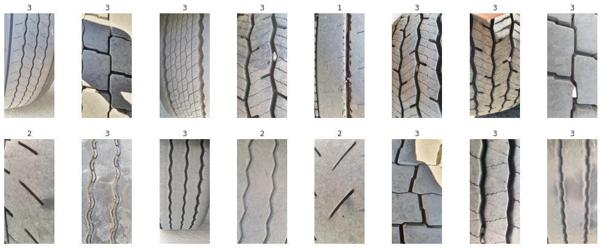

```python
# Sanity check with NO augmented images
plt.figure(figsize=(18, 7))
for images, labels in validation_generator:
    for i in range(16):
        plt.subplot(2, 8, i+1)
        plt.imshow(images[i])
        plt.title(int(np.argmax(labels[i])))
        plt.axis('off')
    break
```

Check class distributions.

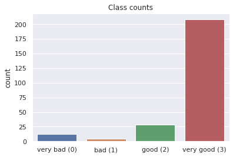

```
Shares of total
Class 0: 0.0476
Class 1: 0.0159
Class 2: 0.1111
Class 3: 0.8254
```

```python
# Check the class distribution
ax = sns.countplot(x=train_generator.classes)
ax.set_xticklabels(['very bad (0)', 'bad (1)', 'good (2)', 'very good (3)']);
plt.title('Class counts')
plt.show()

# Print out shares
n = len(train_generator.classes)
shares = {f'n{i}': round(len(train_generator.classes[train_generator.classes == i])/n, 4) for i in range(4)}
print(f"\nShares of total\nClass 0: {shares['n0']}\nClass 1: {shares['n1']}\nClass 2: {shares['n2']}\nClass 3: {shares['n3']}")
```

We have a significant class imbalance problem here where 82.5% of the data belong to the larger class 3. The smallest class 1 only make up for 1.5% of the total.

## Train a simple model from scratch without Dropout

Start by training a simple model from scratch. Add data augmentation but no Dropout. We will be using the largest class (82.5%) as baseline for the model to beat.

```python
# Define metrics
METRICS = [
           keras.metrics.TruePositives(name='tp'),
           keras.metrics.FalsePositives(name='fp'),
           keras.metrics.TrueNegatives(name='tn'),
           keras.metrics.FalseNegatives(name='fn'),
           keras.metrics.CategoricalAccuracy(name='accuracy'),
           keras.metrics.AUC(name='auc'),
           keras.metrics.AUC(name='prc', curve='PR'),     # precision-recall curve
           keras.metrics.Precision(name='precision'),
           keras.metrics.Recall(name='recall')
]
```

```python
# Create a simple CNN architecture
input_tensor = keras.Input(shape=image_size + (3,), name='input')

x = Conv2D(filters=32, kernel_size=(3, 3), activation='relu')(input_tensor)
x = MaxPooling2D(pool_size=(2, 2))(x)

x = Conv2D(64, (3, 3), activation='relu')(x)
x = MaxPooling2D((2, 2))(x)

x = Conv2D(128, (3, 3), activation='relu')(x)
x = MaxPooling2D((2, 2))(x)
x = Conv2D(128, (3, 3), activation='relu')(x)
x = layers.GlobalAveragePooling2D()(x)

x = Dense(512, activation='relu')(x)
output = Dense(4, activation='softmax', name='output')(x)

model = keras.Model(inputs=[input_tensor], outputs=[output], name='simple_model')
model.compile(loss='categorical_crossentropy',
              optimizer=keras.optimizers.RMSprop(lr=1e-4),
              metrics=METRICS)

model.summary()
```

```
Model: "simple_model"
_________________________________________________________________
Layer (type)                 Output Shape              Param #
=================================================================
input (InputLayer)           [(None, 800, 380, 3)]     0
_________________________________________________________________
conv2d_26 (Conv2D)           (None, 798, 378, 32)      896
_________________________________________________________________
max_pooling2d_21 (MaxPooling (None, 399, 189, 32)      0
_________________________________________________________________
conv2d_27 (Conv2D)           (None, 397, 187, 64)      18496
_________________________________________________________________
max_pooling2d_22 (MaxPooling (None, 198, 93, 64)       0
_________________________________________________________________
conv2d_28 (Conv2D)           (None, 196, 91, 128)      73856
_________________________________________________________________
max_pooling2d_23 (MaxPooling (None, 98, 45, 128)       0
_________________________________________________________________
conv2d_29 (Conv2D)           (None, 96, 43, 128)       147584
_________________________________________________________________
global_average_pooling2d_6 ( (None, 128)               0
_________________________________________________________________
dense_6 (Dense)              (None, 512)               66048
_________________________________________________________________
output (Dense)               (None, 4)                 2052
=================================================================
Total params: 308,932
Trainable params: 308,932
Non-trainable params: 0
_________________________________________________________________
```

```python
print(input_tensor.shape)
print(output.shape)
```

```
(None, 800, 380, 3)
(None, 4)
```

```python
%%time

# Add callback for storing the best model
model_dir = '/content/drive/MyDrive/Tyres/Models/'
try:
    os.mkdir(model_dir)
except FileExistsError:
    pass
callbacks = [
             tf.keras.callbacks.ModelCheckpoint(
                 filepath=model_dir+'model_simple_no_dropout.hdf5',
                 monitor='val_accuracy',
                 save_best_only=True,
                 mode='max'
             )
]

# Train the model
history = model.fit(train_generator,
                    epochs=30,
                    callbacks=callbacks,
                    validation_data=validation_generator,
                    workers=2)
```

```
CPU times: user 17min 19s, sys: 15.3 s, total: 17min 35s
Wall time: 9min 29s
```

```python
# Function for smoothing out the loss and accuracy plots
def smooth(points, factor=0.8):
    smoothed_points = []
    for point in points:
        if smoothed_points:
            previous = smoothed_points[-1]
            smoothed_points.append(previous * factor + point * (1 - factor))
        else:
            smoothed_points.append(point)
    return smoothed_points


def plot_history(hist_dict, soft=False):
    epochs = range(1, len(hist_dict['accuracy']) + 1)

    plt.figure(figsize=(12, 8))

    plt.subplot(2, 2, 1)
    plt.plot(epochs, smooth(hist_dict['loss']) if soft else hist_dict['loss'],
             'bo', label='Train loss')
    plt.plot(epochs, smooth(hist_dict['val_loss']) if soft else hist_dict['val_loss'],
             'b', label='Val loss')
    plt.title('Loss')
    plt.ylabel('Loss')
    plt.legend()

    plt.subplot(2, 2, 2)
    plt.plot(epochs, smooth(hist_dict['accuracy']) if soft else hist_dict['accuracy'],
             'bo', label='Train accuracy')
    plt.plot(epochs, smooth(hist_dict['val_accuracy']) if soft else hist_dict['val_accuracy'],
             'b', label='Val accuracy')
    plt.title('Accuracy')
    plt.ylabel('Accuracy')
    plt.legend()

    plt.subplot(2, 2, 3)
    plt.plot(epochs, smooth(hist_dict['auc']) if soft else hist_dict['auc'],
             'bo', label='Train AUC')
    plt.plot(epochs, smooth(hist_dict['val_auc']) if soft else hist_dict['val_auc'],
             'b', label='Val AUC')
    plt.title('AUC')
    plt.xlabel('Epoch')
    plt.ylabel('AUC')
    plt.legend()

    plt.subplot(2, 2, 4)
    plt.plot(epochs, smooth(hist_dict['precision']) if soft else hist_dict['precision'],
             'bo', label='Train precision')
    plt.plot(epochs, smooth(hist_dict['val_precision']) if soft else hist_dict['val_precision'],
             'b', label='Val precision')
    plt.title('Precision')
    plt.xlabel('Epoch')
    plt.ylabel('Precision')
    plt.legend()

    plt.tight_layout()
    plt.show()
```

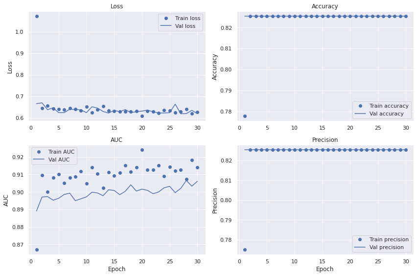

```python
plot_history(history.history)
```

Well, the model seem to learn something at least as the train accuracy increases. However, due to the small network it stagnates very early on. The validation accuracy is always the same at 82.5%, which is equivalent to the largest class. The model is thus seemingly only predicting the largest class. Let us experiment with a larger network.

## Training a larger model from scratch

```python
# Create a larger CNN architecture
input_tensor = keras.Input(shape=image_size + (3,), name='input')

x = SeparableConv2D(filters=32, kernel_size=(3, 3), activation='relu')(input_tensor)
x = MaxPooling2D(pool_size=(2, 2))(x)

x = SeparableConv2D(64, (3, 3), activation='relu')(x)
x = MaxPooling2D((2, 2))(x)
x = SeparableConv2D(64, (3, 3), activation='relu')(x)
x = MaxPooling2D((2, 2))(x)
x = SeparableConv2D(128, (3, 3), activation='relu')(x)
x = MaxPooling2D((2, 2))(x)
x = SeparableConv2D(256, (3, 3), activation='relu')(x)
x = MaxPooling2D((2, 2))(x)
x = SeparableConv2D(512, (3, 3), activation='relu')(x)
x = layers.GlobalAveragePooling2D()(x)
x = Dropout(0.4)(x)

x = Dense(512, activation='relu')(x)
output = Dense(4, activation='softmax', name='output')(x)

model = keras.Model(inputs=[input_tensor], outputs=[output], name='model_large_1')
model.compile(loss='categorical_crossentropy',
              optimizer=keras.optimizers.RMSprop(lr=1e-4),
              metrics=METRICS)
model.summary()
```

```
Model: "model_large_1"
_________________________________________________________________
Layer (type)                 Output Shape              Param #
=================================================================
input (InputLayer)           [(None, 800, 380, 3)]     0
_________________________________________________________________
separable_conv2d_15 (Separab (None, 798, 378, 32)      155
_________________________________________________________________
max_pooling2d_24 (MaxPooling (None, 399, 189, 32)      0
_________________________________________________________________
separable_conv2d_16 (Separab (None, 397, 187, 64)      2400
_________________________________________________________________
max_pooling2d_25 (MaxPooling (None, 198, 93, 64)       0
_________________________________________________________________
separable_conv2d_17 (Separab (None, 196, 91, 64)       4736
_________________________________________________________________
max_pooling2d_26 (MaxPooling (None, 98, 45, 64)        0
_________________________________________________________________
separable_conv2d_18 (Separab (None, 96, 43, 128)       8896
_________________________________________________________________
max_pooling2d_27 (MaxPooling (None, 48, 21, 128)       0
_________________________________________________________________
separable_conv2d_19 (Separab (None, 46, 19, 256)       34176
_________________________________________________________________
max_pooling2d_28 (MaxPooling (None, 23, 9, 256)        0
_________________________________________________________________
separable_conv2d_20 (Separab (None, 21, 7, 512)        133888
_________________________________________________________________
global_average_pooling2d_7 ( (None, 512)               0
_________________________________________________________________
dropout_2 (Dropout)          (None, 512)               0
_________________________________________________________________
dense_7 (Dense)              (None, 512)               262656
_________________________________________________________________
output (Dense)               (None, 4)                 2052
=================================================================
Total params: 448,959
Trainable params: 448,959
Non-trainable params: 0
_________________________________________________________________
```

```python
%%time

# Add callbacks for storing the best model
callbacks = [
             tf.keras.callbacks.ModelCheckpoint(
                 filepath=model_dir+'model_large_1.hdf5',
                 monitor='val_accuracy',
                 save_best_only=True,
                 mode='max'
             )
]

# Train the model
history = model.fit(train_generator,
                    epochs=30,
                    callbacks=callbacks,
                    validation_data=validation_generator,
                    workers=2)
```

```
CPU times: user 17min 51s, sys: 18.9 s, total: 18min 10s
Wall time: 9min 47s
```

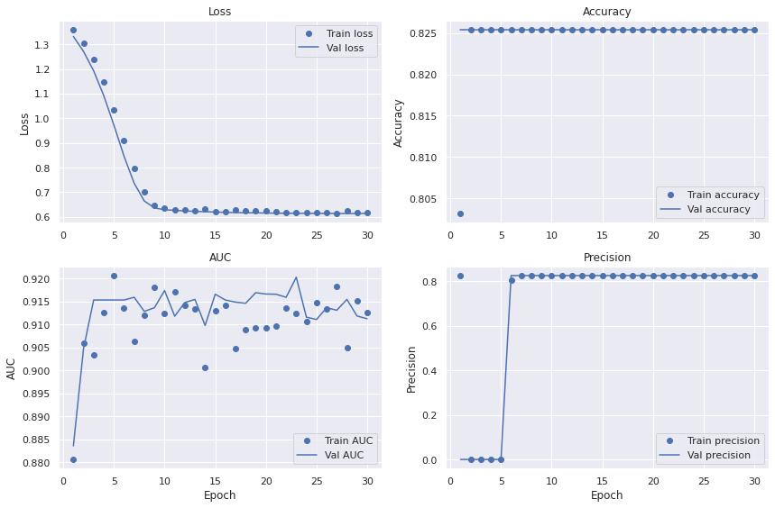

```python
plot_history(history.history)
```

So far, this doesn't look promising. Let's try an even larger model before taking another approach.

## Even larger model from scratch

```python
# Even larger model architecture
input_tensor = keras.Input(shape=image_size + (3,), name='input')

# Entry block
x = layers.Conv2D(32, 3, strides=2, padding="same")(input_tensor)
x = layers.BatchNormalization()(x)
x = layers.Activation("relu")(x)

x = layers.Conv2D(64, 3, padding="same")(x)
x = layers.BatchNormalization()(x)
x = layers.Activation("relu")(x)

previous_block_activation = x  # Set aside residual

for size in [128, 256, 512, 728]:
    x = layers.Activation("relu")(x)
    x = layers.SeparableConv2D(size, 3, padding="same")(x)
    x = layers.BatchNormalization()(x)

    x = layers.Activation("relu")(x)
    x = layers.SeparableConv2D(size, 3, padding="same")(x)
    x = layers.BatchNormalization()(x)

    x = layers.MaxPooling2D(3, strides=2, padding="same")(x)

    # Project residual
    residual = layers.Conv2D(size, 1, strides=2, padding="same")(
        previous_block_activation
    )
    x = layers.add([x, residual])  # Add back residual
    previous_block_activation = x  # Set aside next residual

x = layers.SeparableConv2D(1024, 3, padding="same")(x)
x = layers.BatchNormalization()(x)
x = layers.Activation("relu")(x)

x = layers.GlobalAveragePooling2D()(x)

x = layers.Dropout(0.5)(x)
output = layers.Dense(4, activation='softmax', name='output')(x)

model = keras.Model(input_tensor, output, name='model_large_2')
model.compile(loss='categorical_crossentropy',
              optimizer=keras.optimizers.RMSprop(lr=1e-4),
              metrics=METRICS)
model.summary()
```

```
Model: "model_large_2"
__________________________________________________________________________________________________
Layer (type)                    Output Shape         Param #     Connected to
==================================================================================================
input (InputLayer)              [(None, 800, 380, 3) 0
__________________________________________________________________________________________________
conv2d_30 (Conv2D)              (None, 400, 190, 32) 896         input[0][0]
__________________________________________________________________________________________________
batch_normalization_15 (BatchNo (None, 400, 190, 32) 128         conv2d_30[0][0]
__________________________________________________________________________________________________
activation_11 (Activation)      (None, 400, 190, 32) 0           batch_normalization_15[0][0]
__________________________________________________________________________________________________
conv2d_31 (Conv2D)              (None, 400, 190, 64) 18496       activation_11[0][0]
__________________________________________________________________________________________________
batch_normalization_16 (BatchNo (None, 400, 190, 64) 256         conv2d_31[0][0]
__________________________________________________________________________________________________
activation_12 (Activation)      (None, 400, 190, 64) 0           batch_normalization_16[0][0]
__________________________________________________________________________________________________
activation_13 (Activation)      (None, 400, 190, 64) 0           activation_12[0][0]
__________________________________________________________________________________________________
separable_conv2d_21 (SeparableC (None, 400, 190, 128 8896        activation_13[0][0]
__________________________________________________________________________________________________
batch_normalization_17 (BatchNo (None, 400, 190, 128 512         separable_conv2d_21[0][0]
__________________________________________________________________________________________________
activation_14 (Activation)      (None, 400, 190, 128 0           batch_normalization_17[0][0]
__________________________________________________________________________________________________
separable_conv2d_22 (SeparableC (None, 400, 190, 128 17664       activation_14[0][0]
__________________________________________________________________________________________________
batch_normalization_18 (BatchNo (None, 400, 190, 128 512         separable_conv2d_22[0][0]
__________________________________________________________________________________________________
max_pooling2d_29 (MaxPooling2D) (None, 200, 95, 128) 0           batch_normalization_18[0][0]
__________________________________________________________________________________________________
conv2d_32 (Conv2D)              (None, 200, 95, 128) 8320        activation_12[0][0]
__________________________________________________________________________________________________
add_16 (Add)                    (None, 200, 95, 128) 0           max_pooling2d_29[0][0]
                                                                 conv2d_32[0][0]
__________________________________________________________________________________________________
activation_15 (Activation)      (None, 200, 95, 128) 0           add_16[0][0]
__________________________________________________________________________________________________
separable_conv2d_23 (SeparableC (None, 200, 95, 256) 34176       activation_15[0][0]
```

[output cut: 55 more lines]

```
__________________________________________________________________________________________________
batch_normalization_25 (BatchNo (None, 25, 12, 1024) 4096        separable_conv2d_29[0][0]
__________________________________________________________________________________________________
activation_21 (Activation)      (None, 25, 12, 1024) 0           batch_normalization_25[0][0]
__________________________________________________________________________________________________
global_average_pooling2d_8 (Glo (None, 1024)         0           activation_21[0][0]
__________________________________________________________________________________________________
dropout_3 (Dropout)             (None, 1024)         0           global_average_pooling2d_8[0][0]
__________________________________________________________________________________________________
output (Dense)                  (None, 4)            4100        dropout_3[0][0]
==================================================================================================
Total params: 2,785,724
Trainable params: 2,776,988
Non-trainable params: 8,736
__________________________________________________________________________________________________
```

```python
%%time

# Add callbacks for storing the best model
callbacks = [
             tf.keras.callbacks.ModelCheckpoint(
                 filepath=model_dir+'model_large_2.hdf5',
                 monitor='val_accuracy',
                 save_best_only=True,
                 mode='max'
             )
]

# Train the model
history = model.fit(train_generator,
                    epochs=30,
                    callbacks=callbacks,
                    validation_data=validation_generator,
                    workers=2)
```

```
CPU times: user 20min 1s, sys: 30.2 s, total: 20min 31s
Wall time: 12min 2s
```

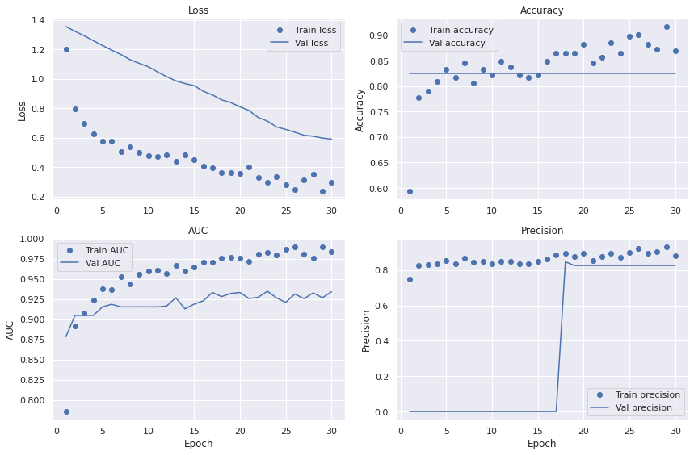

```python
plot_history(history.history)
```

```python
!nvidia-smi
```

[output not shown]

We can confirm that the model consistently predicts everything as belonging to class 3.

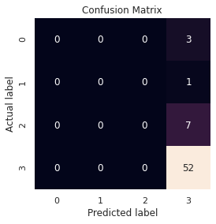

```python
def plot_cm(labels, predictions):
    cm = tf.math.confusion_matrix(labels=labels,
                                  predictions=predictions)
    plt.figure(figsize=(4,4))
    sns.heatmap(cm, annot=True, cbar=False, fmt='d')
    plt.title('Confusion Matrix')
    plt.ylabel('Actual label')
    plt.xlabel('Predicted label')
    plt.show();


# Make predictions on the validation set (which is not ideal! But that's what we have.)
best_model = keras.models.load_model(model_dir+'model_large_2.hdf5')  # Load the best performing model
predictions = best_model.predict(validation_generator)

# Plot confusion matrix
plot_cm(validation_generator.classes,
        np.argmax(predictions, axis=1))
```

```python
print(f"Predictions: \n{np.argmax(predictions, axis=1)}")
print(f"\nTrue labels: \n{validation_generator.classes}")
```

```
Predictions:
[3 3 3 3 3 3 3 3 3 3 3 3 3 3 3 3 3 3 3 3 3 3 3 3 3 3 3 3 3 3 3 3 3 3 3 3 3
 3 3 3 3 3 3 3 3 3 3 3 3 3 3 3 3 3 3 3 3 3 3 3 3 3 3]

True labels:
[0 0 0 1 2 2 2 2 2 2 2 3 3 3 3 3 3 3 3 3 3 3 3 3 3 3 3 3 3 3 3 3 3 3 3 3 3
 3 3 3 3 3 3 3 3 3 3 3 3 3 3 3 3 3 3 3 3 3 3 3 3 3 3]
```

## Using pre-trained models (Transfer Learning)

Use an Xception architecture pre-trained on Imagenet.

It's necessary to freeze the convolution base of a pre-trained model as Xception in order to train a randomly initiated classifier on top. Conversely, **it's highly recommended to fine-tune the top layers of a convolutional base once the classifier on top has already been trained**. If the classifier hasn't been trained, then the error signal propagating through the network during training will be too large, and the representations previously learned by the layers being fine-tuned will be destroyed. For that reason, the steps moving forward will be:

- 1) Add a custom classifier on top of the already-trained Xception base network.
- 2) Freeze the Xception base.
- 3) Train the custom network added on top.
- 4) Unfreeze some layers in the Xception base network.
- 5) Jointly train both these layers and the added classifier on top with a very low learning rate.

```python
# Instantiate the Xception convolutional base
conv_base = keras.applications.Xception(weights='imagenet',
                                       include_top=False,)
conv_base.summary()
```

```
Model: "xception"
__________________________________________________________________________________________________
Layer (type)                    Output Shape         Param #     Connected to
==================================================================================================
input_2 (InputLayer)            [(None, None, None,  0
__________________________________________________________________________________________________
block1_conv1 (Conv2D)           (None, None, None, 3 864         input_2[0][0]
__________________________________________________________________________________________________
block1_conv1_bn (BatchNormaliza (None, None, None, 3 128         block1_conv1[0][0]
__________________________________________________________________________________________________
block1_conv1_act (Activation)   (None, None, None, 3 0           block1_conv1_bn[0][0]
__________________________________________________________________________________________________
block1_conv2 (Conv2D)           (None, None, None, 6 18432       block1_conv1_act[0][0]
__________________________________________________________________________________________________
block1_conv2_bn (BatchNormaliza (None, None, None, 6 256         block1_conv2[0][0]
__________________________________________________________________________________________________
block1_conv2_act (Activation)   (None, None, None, 6 0           block1_conv2_bn[0][0]
__________________________________________________________________________________________________
block2_sepconv1 (SeparableConv2 (None, None, None, 1 8768        block1_conv2_act[0][0]
__________________________________________________________________________________________________
block2_sepconv1_bn (BatchNormal (None, None, None, 1 512         block2_sepconv1[0][0]
__________________________________________________________________________________________________
block2_sepconv2_act (Activation (None, None, None, 1 0           block2_sepconv1_bn[0][0]
__________________________________________________________________________________________________
block2_sepconv2 (SeparableConv2 (None, None, None, 1 17536       block2_sepconv2_act[0][0]
__________________________________________________________________________________________________
block2_sepconv2_bn (BatchNormal (None, None, None, 1 512         block2_sepconv2[0][0]
__________________________________________________________________________________________________
conv2d_36 (Conv2D)              (None, None, None, 1 8192        block1_conv2_act[0][0]
__________________________________________________________________________________________________
block2_pool (MaxPooling2D)      (None, None, None, 1 0           block2_sepconv2_bn[0][0]
__________________________________________________________________________________________________
batch_normalization_26 (BatchNo (None, None, None, 1 512         conv2d_36[0][0]
__________________________________________________________________________________________________
add_20 (Add)                    (None, None, None, 1 0           block2_pool[0][0]
                                                                 batch_normalization_26[0][0]
__________________________________________________________________________________________________
block3_sepconv1_act (Activation (None, None, None, 1 0           add_20[0][0]
__________________________________________________________________________________________________
block3_sepconv1 (SeparableConv2 (None, None, None, 2 33920       block3_sepconv1_act[0][0]
```

[output cut: 229 more lines]

```
__________________________________________________________________________________________________
block14_sepconv1_bn (BatchNorma (None, None, None, 1 6144        block14_sepconv1[0][0]
__________________________________________________________________________________________________
block14_sepconv1_act (Activatio (None, None, None, 1 0           block14_sepconv1_bn[0][0]
__________________________________________________________________________________________________
block14_sepconv2 (SeparableConv (None, None, None, 2 3159552     block14_sepconv1_act[0][0]
__________________________________________________________________________________________________
block14_sepconv2_bn (BatchNorma (None, None, None, 2 8192        block14_sepconv2[0][0]
__________________________________________________________________________________________________
block14_sepconv2_act (Activatio (None, None, None, 2 0           block14_sepconv2_bn[0][0]
==================================================================================================
Total params: 20,861,480
Trainable params: 20,806,952
Non-trainable params: 54,528
__________________________________________________________________________________________________
```

```python
# Add a densely connected classifier on top of the convolutional base
input_tensor = keras.Input(shape=(image_size) + (3,), name='input')
x = conv_base(input_tensor)
x = layers.Flatten()(x)
x = Dense(128, activation='relu')(x)
output = Dense(4, activation='softmax', name='output')(x)

model = keras.Model(inputs=input_tensor, outputs=output, name='Xception_1')
model.summary()
```

```
Model: "Xception_1"
_________________________________________________________________
Layer (type)                 Output Shape              Param #
=================================================================
input (InputLayer)           [(None, 800, 380, 3)]     0
_________________________________________________________________
xception (Functional)        (None, None, None, 2048)  20861480
_________________________________________________________________
flatten_1 (Flatten)          (None, 614400)            0
_________________________________________________________________
dense_8 (Dense)              (None, 128)               78643328
_________________________________________________________________
output (Dense)               (None, 4)                 516
=================================================================
Total params: 99,505,324
Trainable params: 99,450,796
Non-trainable params: 54,528
_________________________________________________________________
```

Freeze the convolutional base before compiling and training the model. Very important!

```python
print("Number of trainable parameters BEFORE freezing the conv base:", len(model.trainable_weights))

# Freeze conv base
conv_base.trainable = False
print("Number of trainable parameters AFTER freezing the conv base:", len(model.trainable_weights))
```

```
Number of trainable parameters BEFORE freezing the conv base: 158
Number of trainable parameters AFTER freezing the conv base: 4
```

```python
# Compile the model and take and make sure there a fewer trainable parameters now
model.compile(loss='categorical_crossentropy',
              optimizer=keras.optimizers.RMSprop(lr=1e-5), # Lower learning rate
              metrics=METRICS)
model.summary()
```

```
Model: "Xception_1"
_________________________________________________________________
Layer (type)                 Output Shape              Param #
=================================================================
input (InputLayer)           [(None, 800, 380, 3)]     0
_________________________________________________________________
xception (Functional)        (None, None, None, 2048)  20861480
_________________________________________________________________
flatten_1 (Flatten)          (None, 614400)            0
_________________________________________________________________
dense_8 (Dense)              (None, 128)               78643328
_________________________________________________________________
output (Dense)               (None, 4)                 516
=================================================================
Total params: 99,505,324
Trainable params: 78,643,844
Non-trainable params: 20,861,480
_________________________________________________________________
```

```python
%%time

# Add callbacks for storing the best model as well as early stopping
callbacks = [
             tf.keras.callbacks.ModelCheckpoint(
                 filepath=model_dir+'Xception_1.hdf5',
                 monitor='val_accuracy',
                 save_best_only=True,
                 mode='max'
             ),
             tf.keras.callbacks.EarlyStopping(
                 monitor='val_accuracy',
                 patience=10, # Stop training if the val_accuracy doesn't improve over 10 epochs.
                 mode='max',
                 restore_best_weights=True,
             )
]

# Train the model using the same train and validation generators as before
history = model.fit(train_generator,
                    epochs=100,
                    callbacks=callbacks,
                    validation_data=validation_generator,
                    workers=2)
```

```
CPU times: user 14min 36s, sys: 28.5 s, total: 15min 4s
Wall time: 8min 29s
```

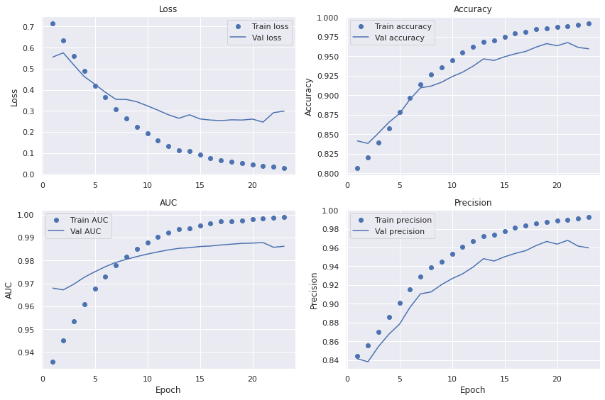

```python
plot_history(history.history, soft=True)
```

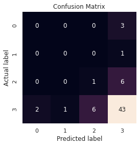

```python
# Make predictions on the validation set (which is not ideal!) with the best model
best_model = keras.models.load_model(model_dir+'Xception_1.hdf5')  # Load the best performing model
predictions = best_model.predict(validation_generator)

# Plot confusion matrix
plot_cm(validation_generator.classes,
        np.argmax(predictions, axis=1))
```

## Fine-tune the pre-trained model

Move on to the last two steps:

- 4) Unfreeze some layers from the convolution base
- 5) Jointly train both these unfreezed layers and the now trained classifier in top.

Unfreeze the last six layers belonging to "block14" (this can later be re-adjusted).

```python
# Start by setting all layers as trainable
conv_base.trainable = True

# Freeze the layers belonging to "block14"
set_trainable = False
for layer in conv_base.layers:
    if 'block14_sep' in layer.name:
        set_trainable = True
    if set_trainable:
        layer.trainable = True
    else:
        layer.trainable = False

# Check how the model looks like now
model.summary()
```

```
Model: "Xception_1"
_________________________________________________________________
Layer (type)                 Output Shape              Param #
=================================================================
input (InputLayer)           [(None, 800, 380, 3)]     0
_________________________________________________________________
xception (Functional)        (None, None, None, 2048)  20861480
_________________________________________________________________
flatten_1 (Flatten)          (None, 614400)            0
_________________________________________________________________
dense_8 (Dense)              (None, 128)               78643328
_________________________________________________________________
output (Dense)               (None, 4)                 516
=================================================================
Total params: 99,505,324
Trainable params: 83,392,644
Non-trainable params: 16,112,680
_________________________________________________________________
```

```python
%%time

# Compile the model
model.compile(loss='categorical_crossentropy',
              optimizer=keras.optimizers.RMSprop(lr=2e-6), # Lower learning rate
              metrics=METRICS)

# Add callbacks for storing the best model
callbacks = [
             tf.keras.callbacks.ModelCheckpoint(
                 filepath=model_dir+'Xception_2_fine_tuned.hdf5',
                 monitor='val_accuracy',
                 save_best_only=True,
                 mode='max'
             )
]

# Train the model using the same train and validation generators as before
history = model.fit(train_generator,
                    epochs=30,
                    callbacks=callbacks,
                    validation_data=validation_generator,
                    workers=2)
```

```
CPU times: user 19min 21s, sys: 36.2 s, total: 19min 58s
Wall time: 10min 54s
```

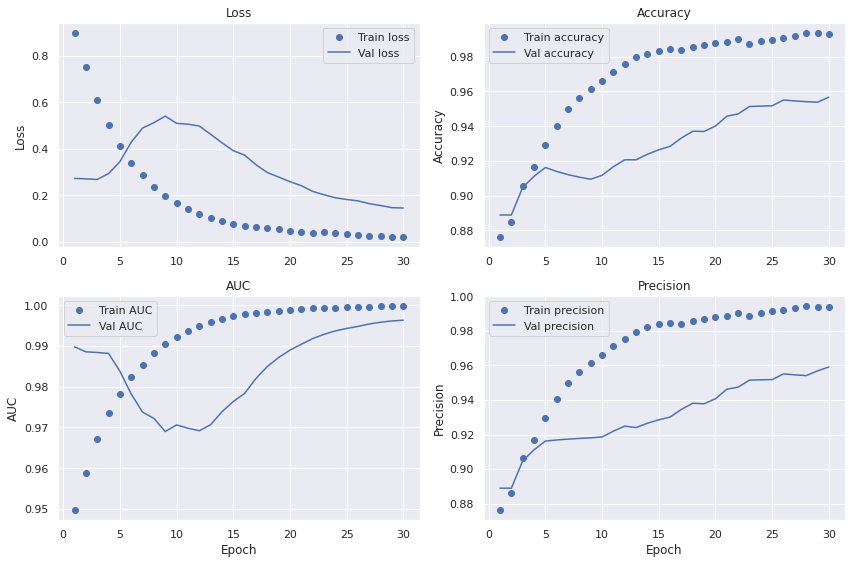

```python
plot_history(history.history, soft=True)
```

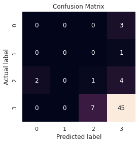

```python
# Make predictions with the best model
best_model = keras.models.load_model(model_dir+'Xception_2_fine_tuned.hdf5')  # Load the best performing model
predictions = best_model.predict(validation_generator)

# Plot confusion matrix
plot_cm(validation_generator.classes,
        np.argmax(predictions, axis=1))
```

## Summary

This initial experiment indicate that it is possible to learn to classify the thread depth of tyres by training a deep learning model on single camera input images. Although the more basic architectures trained from scratch failed to yield useful results, making use of transfer learning and an Xception model pre-trained on ImageNet indicates that this can possibly be done. This despite using a very small dataset of a total 315 images with significant class imbalance. It's also very important to note that the performance has been calculated on the validation set as the data was too small to be split into three pieces; train, validation and test sets.

The first thing to address moving forward would be to collect more data. That would allow us to more confidently assess how the model performs. Another consideration is also whether it's easier to take an accurate photo of a tyre rather than just using current methods available on the market.